# Analisis Kontribusi Kategori Film terhadap Pendapatan Store: Strategi Pemasaran Berdasarkan Preferensi Kategori Film

DAVIKA DARRYN PUANNAJWA

2026-05-20

# Pendahuluan

Laporan ini berisi hasil analisis perbandingan kontribusi pendapatan berdasarkan kategori film antara store 1 dan 2 dengan sumber data dari database Sakila yang merupakan database toko rental film di MySQL. Laporan ini menggunakan 4 variabel utama yaitu *amount* sebagai pendapatan, *name* sebagai kategori film, store_id, dan rental_id. Analisis dilakukan dengan menggunakan software RStudio yang diintegrasikan dengan MySQL Workbench untuk pengambilan data.

# Deskripsi Insight

Dengan empat variabel yang diambil, akan dianalisis kontribusi pendapatan berdasarkan kategori film untuk store 1 dan 2 untuk melihat apakah ada perbedaan kontribusi kategori. Pertama, data diambil dengan menjumlah pendapatan yang dibagi berdasarkan kategori untuk masing-masing store. Hasil agregasi data kemudian dibuat dalam bentuk persentase kemudian divisualisasikan untuk memberikan gambaran distribusi tiap kategori. Setelah dilakukan visualisasi, akan dilakukan analisis menggunakan uji chi-square frekuensi pinjam per kategori film untuk melihat secara statistik apakah terdapat perbedaan untuk preferensi store 1 dan 2. Dengan mengetahui perbedaan dari segi pendapatan dan preferensi kategori antar kedua store, diharapkan analisis ini dapat dijadikan dasar strategi dalam menyusun persediaan film yang optimal berdasarkan preferensi serta meningkatkan pendapatan masing-masing store.

# Data dan Visualisasi

Berikut adalah langkah-langkah untuk membuat visualisasi dan analisis data. Langkah ini terbagi menjadi 3 yaitu membuat koneksi, membuat visualisasi, dan menguji menggunakan metode statistik chi-square.

## Membuat Koneksi R dengan Database

Sebelum melakukan koneksi, perlu untuk menginstall beberapa packages yang memuat fungsi koneksi kemudian mengaktifkannya.Selanjutnya, gunakan fungsi dbConnect() untuk membuat koneksi dengan memasukkan password user SQL kita dan database yang akan digunakan.

```r
library("DBI")
library("odbc")

odbc::odbcListDrivers()
con3 = dbConnect(odbc(),

                     Driver = "MySQL ODBC 8.0 ANSI Driver",

                     Server = "127.0.0.1",

                     UID = "root",

                     PWD = "isi password akun",

                     Port = 3306,
                     Database = "sakila")
```

## Visualisasi Distribusi Pendapatan per Kategori untuk Masing-Masing Store

Setelah terbentuk koneksi antara R dengan database Sakila di MySQL, kita akan mengambil data menggunakan fungsi dbGetQuery(). Data yang digunakan adalah jumlah amount sebagai pendapatan kemudian dibagi dalam grup berdasarkan kategori film dan di filter untuk menampilkan store 1 atau store 2 saja menggunakan atribut store_id.

```r
laba_kategori_s1 = dbGetQuery(con3,"SELECT SUM(amount) AS pendapatan, `name` AS kategori_film
FROM payment JOIN rental USING (rental_id)
JOIN inventory USING (inventory_id)
JOIN film_category USING (film_id)
JOIN category USING (category_id)
WHERE store_id = 1
GROUP BY kategori_film
ORDER BY pendapatan DESC")
laba_kategori_s1
```

```
##    pendapatan kategori_film
## 1     2573.24         Drama
## 2     2488.46        Sports
## 3     2402.98           New
## 4     2377.97        Comedy
## 5     2342.04        Action
## 6     2297.29     Animation
## 7     2289.77       Foreign
## 8     2203.79        Sci-Fi
## 9     2166.44        Family
## 10    2083.46         Games
## 11    1869.51   Documentary
## 12    1795.66         Music
## 13    1758.47      Children
## 14    1717.51      Classics
## 15    1673.14        Horror
## 16    1640.06        Travel
```

```r
laba_kategori_s2 = dbGetQuery(con3,"SELECT SUM(amount) AS pendapatan, `name` AS kategori_film
FROM payment JOIN rental USING (rental_id)
JOIN inventory USING (inventory_id)
JOIN film_category USING (film_id)
JOIN category USING (category_id)
WHERE store_id = 2
GROUP BY kategori_film
ORDER BY pendapatan DESC")
laba_kategori_s2
```

```
##    pendapatan kategori_film
## 1     2825.75        Sports
## 2     2553.19        Sci-Fi
## 3     2359.01     Animation
## 4     2348.01   Documentary
## 5     2197.87         Games
## 6     2059.63        Family
## 7     2049.40        Horror
## 8     2033.81        Action
## 9     2014.15         Drama
## 10    2005.61        Comedy
## 11    1980.90       Foreign
## 12    1948.64           New
## 13    1922.08      Classics
## 14    1909.58        Travel
## 15    1897.08      Children
## 16    1622.06         Music
```

Pendapatan tiap kategori kemudian diubah dalam bentuk persen

```r
nilai1<-round(laba_kategori_s1$pendapatan/sum(laba_kategori_s1$pendapatan)*100, 2)
nilai2<-round(laba_kategori_s2$pendapatan/sum(laba_kategori_s2$pendapatan)*100,2)
```

Selanjutnya, dilakukan visualisasi data dengan menggunakan fungsi ggplot() untuk membuat bar chart yang diurutkan berdasarkan kontribusi pendapatan (dalam persen) dari yang tertinggi ke terendah.

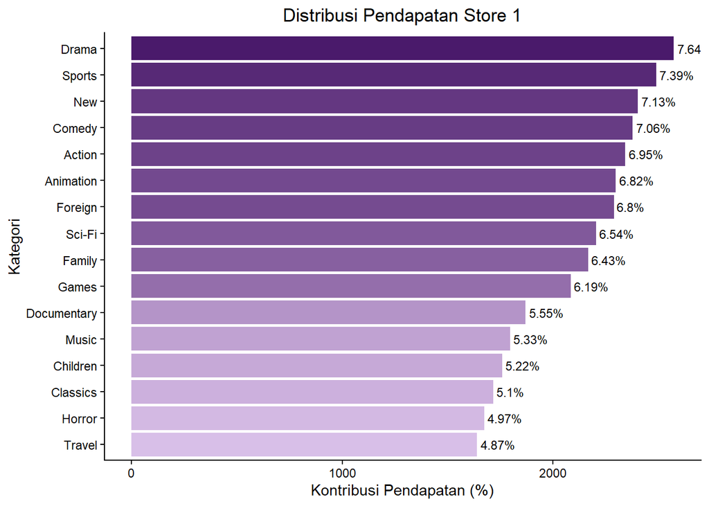

```r
library("ggplot2")
library("dplyr")

bar_s1 <- ggplot(laba_kategori_s1, aes(x = reorder(kategori_film, pendapatan),
                                       y = pendapatan, fill = pendapatan)) +
  geom_bar(stat = "identity") +
  geom_text(aes(label = paste0(nilai1, "%")),
            hjust = -0.1, size = 3) +
  coord_flip() +
  scale_fill_gradient(low = "#D8BFE8", high = "#4A1A6B") +
  labs(x = "Kategori", y = "Kontribusi Pendapatan (%)", fill = NULL,
       title = "Distribusi Pendapatan Store 1") +
  theme_classic() +
  theme(legend.position = "none",
        plot.title = element_text(hjust = 0.5, color = "black"))

bar_s1
```

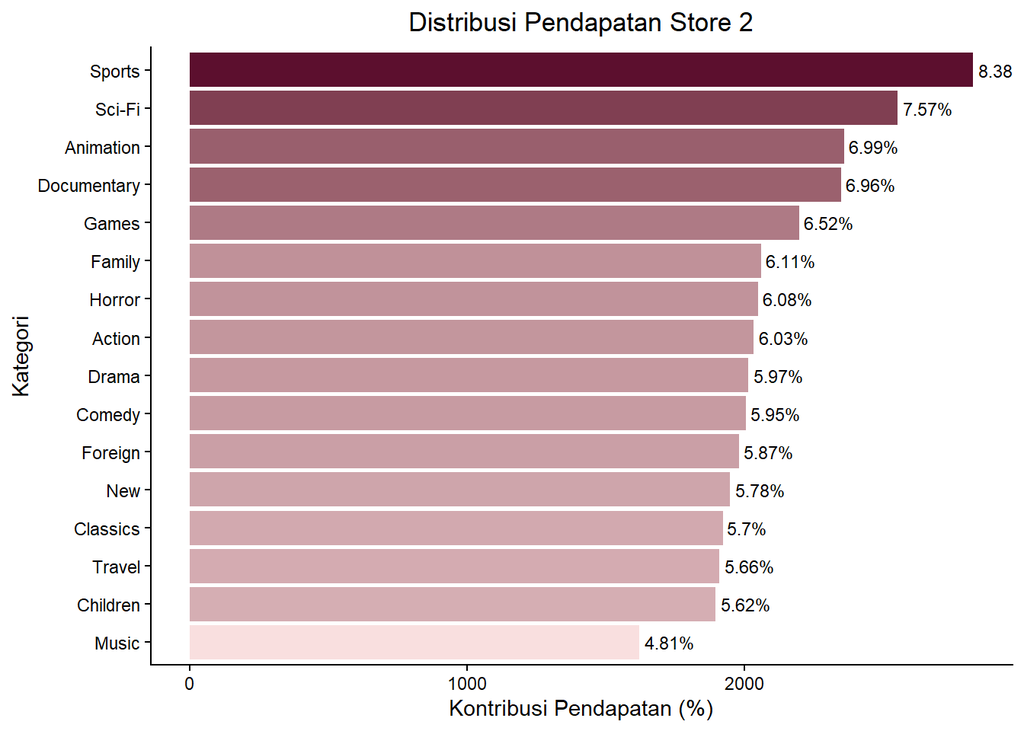

```r
bar_s2 <- ggplot(laba_kategori_s2, aes(x = reorder(kategori_film, pendapatan),
                                       y = pendapatan, fill = pendapatan)) +
  geom_bar(stat = "identity") +
  geom_text(aes(label = paste0(nilai2, "%")),
            hjust = -0.1, size = 3) +
  coord_flip() +
  scale_fill_gradient(low = "#F9DFDF", high = "#5C0F2E") +
  labs(x = "Kategori", y = "Kontribusi Pendapatan (%)", fill = NULL,
       title = "Distribusi Pendapatan Store 2") +
  theme_classic() +
  theme(legend.position = "none",
        plot.title = element_text(hjust = 0.5, color = "black"))

bar_s2
```

Berdasarkan hasil visualisasi, terlihat bahwa terdapat perbedaan urutan kategori yang paling banyak berkontribusi terhadap pendapatan store 1 dan 2. Store 1 memperoleh pendapatan tinggi pada kategori film drama dengan pendapatan sebesar 2573.24 USD (7.64%) sedangkan store 2 memperoleh pendapatan tinggi dari kategori film sport dengan pendapatan sebesar 2825.75 USD (8.38%). Dengan 16 kategori film, distribusi secara merata akan menunjukkan 6.25% untuk masing-masing kategori. Store 2 memiliki nilai dominasi yang paling jauh (8.38%) dari nilai standar, artinya dominasi pendapatan kategori tampak lebih kuat di store 2. Namun, apakah perbedaan pendapatan ini juga menunjukkan preferensi kategori ini benar-benar berbeda? Hal ini akan kita buktikan dengan menguji menggunakan uji chi-square.

## Analisis Uji Statistik Chi-Square

Uji chi-square adalah uji non-parametrik yang dilakukan untuk data berbentuk kategori atau nominal. Uji chi-square digunakan untuk melihat hubungan atau kesesuaian data. Dalam konteks laporan ini, akan digunakan uji chi-square *test of independence* untuk menguji apakah ada hubungan signifikan antara kategori film yang dipinjam dengan store. Lebih lanjut, uji ini akan membuktikan apakah perbedaan preferensi kategori film antara store 1 dan 2 memang berbeda atau hanya kebetulan pada visualisasi namun tidak memiliki nilai perbedaan yang bermakna.

Untuk memulai uji ini, kita akan menentukan hipotesis awal (H0) dan hipotesis alternatif (H1). Hipotesis alternatif adalah hipotesis yang ingin kita uji kebenarannya, sementara hipotesis awal merupakan hipotesis yang berkebalikan dari hipotesis alternatif.

$$\begin{align}
H_0&: \text{Tidak terdapat perbedaan preferensi kategori film antara
Store 1 dan Store 2} \\
H_1&: \text{Terdapat perbedaan preferensi kategori film antara Store
1 dan Store 2}
\end{align}$$

Data yang digunakan untuk uji ini adalah banyak rental_id sebagai frekuensi pinjam per kategori film antar store. Selanjutnya, uji chi-square akan dilakukan dengan fungsi chisq.test() dari R dengan tingkat signifikansi atau $\alpha=0.05$ . Apabila hasil *p-value* < 0.05 artinya H0 ditolak dan *p-value* > 0.05 artinya gagal tolak H0.

```r
frek_s1<-dbGetQuery(con3,"SELECT COUNT(rental_id) AS frekuensi_pinjam, `name` AS kategori_film
FROM rental JOIN inventory USING(inventory_id)
JOIN film_category USING (film_id)
JOIN category USING (category_id)
WHERE store_id = 1
GROUP BY kategori_film")
frek_s2<-dbGetQuery(con3,"SELECT COUNT(rental_id) AS frekuensi_pinjam, `name` AS kategori_film
FROM rental JOIN inventory USING(inventory_id)
JOIN film_category USING (film_id)
JOIN category USING (category_id)
WHERE store_id = 2
GROUP BY kategori_film")

#Ubah frekuensi pinjam agar berbentuk numerik
frek_s1$frekuensi_pinjam <- as.numeric(frek_s1$frekuensi_pinjam)
frek_s2$frekuensi_pinjam <- as.numeric(frek_s2$frekuensi_pinjam)

#urutkan berdasarkan kategori film untuk kedua store
frek_s1 <- frek_s1 %>% arrange(kategori_film)
frek_s2 <- frek_s2 %>% arrange(kategori_film)

#penggabungan 2 data (frek_s1 dan frek_s2) menjadi satu dengan kategori film sebagai kolom dan store sebagai baris
frek_kontingen <- rbind(
  frek_s1$frekuensi_pinjam,
  frek_s2$frekuensi_pinjam
)
colnames(frek_kontingen) <- frek_s1$kategori_film
rownames(frek_kontingen) <- c("Store 1", "Store 2")

# Uji Chi-Square
chisq.test(frek_kontingen)
```

```
##
##  Pearson's Chi-squared test
##
## data:  frek_kontingen
## X-squared = 68.392, df = 15, p-value = 8.625e-09
```

Hasil analisis menunjukkan nilai *p-value* sebesar $8.625 \times 10^{-9}$. Karena nilai *p-value* dibawah 0.05, H0 ditolak yang berarti terbukti bahwa terdapat perbedaan nyata preferensi kategori antara store 1 dan 2. Df dalam hasil chunk merupakan derajat kebebasan (*degree freedom*) yang diperoleh dari
$$(a-1) \times
(b-1)=(16-1) \times (2-1)=15$$
dengan *a* sebagai kategori film dan *b* sebagai store. Nilai ini menunjukkan jumlah sel dalam tabel data yang bervariasi dengan bebas dari total frekuensi baris dan kolom yang ada.

# Kesimpulan

Berdasarkan hasil visualisasi dan analisis uji statistik, terbukti bahwa kedua store memiliki distribusi pendapatan dan preferensi kategori yang berbeda. Film kategori drama berkontribusi lebih banyak terhadap pendapatan store 1 sementara film kategori sports berkontribusi lebih banyak terhadap pendapatan store 2. Hasil dari uji chi-square juga menunjukkan bahwa preferensi kategori antar store memang berbeda secara statistik. Namun, karena distribusi store relatif merata (tidak jauh dari nilai standar yaitu 6.25%) maka bisa dikatakan bahwa perbedaan kontribusi tidak begitu jauh atau ekstrem. Karena itu, toko rental bisa mempertimbangkan untuk menambah film kategori drama di store 1 dan sports di store 2 dan mempertahankan ketersediaan stok kategori lain.